# Ejemplo de Rmarkdown

Diplomado en Análisis de datos con R para la acuicultura

Dr. José A. Gallardo y Dra. María Angélica Rueda.

Pontificia Universidad Católica de Valparaíso  
jose.gallardo@pucv.cl

22/4/2021

## Metadata

Este script contiene toda la información necesaria para generar un reporte dinámico. Al inicio usted puede observar la **metadata** del documento en formato **YAML**.

## Markdown

Este texto que usted lee ahora se denomina markdown y puede modificarlo a voluntad cuando escriba un reporte, agregando todo tipo de formatos, así como tablas, listas, párrafos o referencias.

**Viñetas y listas numeradas**

```
1. Elemento 1
2. Elemento 2
3. Elemento 3
```

1. Elemento 1
2. Elemento 2
3. Elemento 3

**Escribir en negrita o cursiva**

```
**negrita** *cursiva*
```

**negrita** *cursiva*

**Crear tablas**

```
Variable A | Variable B
-- | --
Campo A1 | Campo B1
Campo A2 | Campo B2
```

| Variable A | Variable B |
| --- | --- |
| Campo A1 | Campo B1 |
| Campo A2 | Campo B2 |

## Bloques de código o chunk

La principal diferencia de Markdown con RMarkdown es obviamente la posibilidad de incluir códigos de R para analizar datos. Esto se consigue agregando bloques de códigos como el que se muestra a continuación. Observe con detención que el bloque de códigos comienza y termina con 3 tildes invertidas **```** y que al inicio hay una r entre dos **{}** lo que indica al software que es un código de **R**. Éste primer bloque es para configurar el resto de los bloques de código, por eso se ha incluido un nombre **setup**. En este primer **chunk** puede ver el llamado a ejecutar la librería **knitr**. Investigue la utilidad de los argumentos adicionales como **include=FALSE** y **echo=TRUE**.

Cuando trabajes con bloques de códigos para analizar tus datos, también puedes agregar el nombre del bloque del código, en este caso **BOD**.

Mientras que para ejecutar este código, debes presionar **la punta de la flecha verde** que se observa en la parte superior derecha del mismo bloque de códigos.

```r
summary(BOD)
```

```
##       Time           demand
##  Min.   :1.000   Min.   : 8.30
##  1st Qu.:2.250   1st Qu.:11.62
##  Median :3.500   Median :15.80
##  Mean   :3.667   Mean   :14.83
##  3rd Qu.:4.750   3rd Qu.:18.25
##  Max.   :7.000   Max.   :19.80
```

También puede incluir gráficas en sus bloques de código.

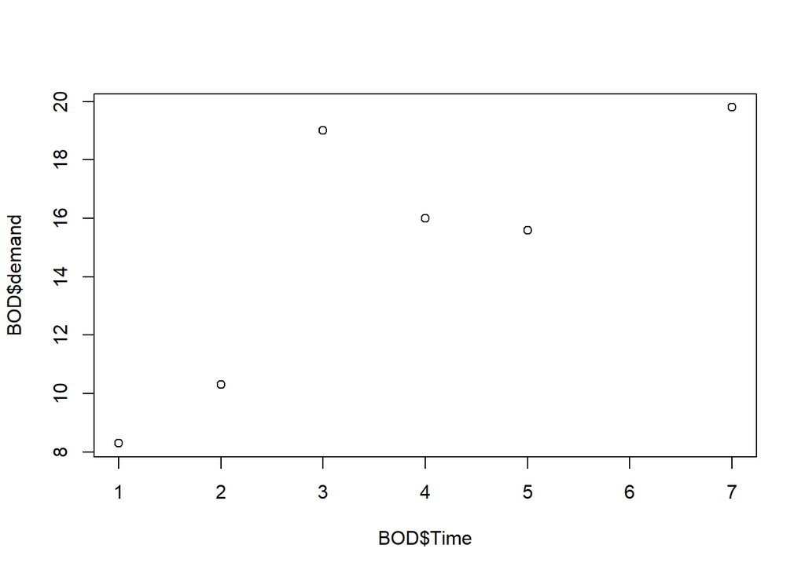

Figura 1. Demanda biológica de oxígeno en función del tiempo

### Elaborar un reporte

Finalmente, para poder generar un reporte debes presionar el **triángulo negro** que está junto a la palabra **Knit** en la parte superior de este documento. Si presionas **Knit to HTML**, esto indicará a la librería **knitr** que debe leer el presente documento, interpretar y ejecutar el metadata, el texto de bajo nivel y los diferentes bloques de código.

Para finalizar, pruebe generar dos reportes adicionales uno en formato pdf y otro en formato word. Compare los documentos e identifique sus diferencias.

Para más detalles de como trabajar con Rmarkdown investigue el siguiente link https://www.rstudio.com/wp-content/uploads/2015/03/rmarkdown-spanish.pdf